# Regresión Modelos Métodos PEC 1

Raúl Pérez Prats

2024-04-27

# Tabla de contenidos

## 1. Ejercicio 1

## 2. Ejercicio 2

## 3. Ejercicio 3

## 4. Apéndices

## 1.

### A)

```r
lmod_inicial <- lm(sysBP ~ BMI * male, data=mydat_no_NA) # Modelo con interacción entre BMI y male

summary(lmod_inicial) # Mostrar resumen del modelo
```

```
##
## Call:
## lm(formula = sysBP ~ BMI * male, data = mydat_no_NA)
##
## Residuals:
##     Min      1Q  Median      3Q     Max
## -52.676 -14.462  -3.421  10.271 134.458
##
## Coefficients:
##             Estimate Std. Error t value Pr(>|t|)
## (Intercept)  80.9411     2.6398  30.661  < 2e-16 ***
## BMI           2.0505     0.1019  20.129  < 2e-16 ***
## male         15.7143     4.7948   3.277  0.00106 **
## BMI:male     -0.7259     0.1830  -3.967 7.41e-05 ***
## ---
## Signif. codes:  0 '***' 0.001 '**' 0.01 '*' 0.05 '.' 0.1 ' ' 1
##
## Residual standard error: 20.75 on 3654 degrees of freedom
## Multiple R-squared:  0.1182, Adjusted R-squared:  0.1174
## F-statistic: 163.2 on 3 and 3654 DF,  p-value: < 2.2e-16
```

En el resumen del modelo, se evidencia una relación significativa entre el índice de masa corporal (BMI) y la presión arterial sistólica (sysBP), ya que el p-valor asociado es menor que 0.05. Esto indica que el BMI influye de manera significativa en las predicciones de sysBP en nuestro modelo lineal. Específicamente, por cada unidad de aumento en BMI, se espera un incremento de aproximadamente 2.05 en sysBP.

El valor de R-cuadrado ajustada es 0.1174 e indica que tan solo el 12% (aprox) de la varianza de la presión arterial sistólica es explicado por lmod_inicial. Pese a que este modelo es significativo (p-valor < 0.05) hay un 88% de la varianza de sysBP no explicada y, por lo tanto, es necesario incluir más variables para explicar la varianza de sysBP.

### B)

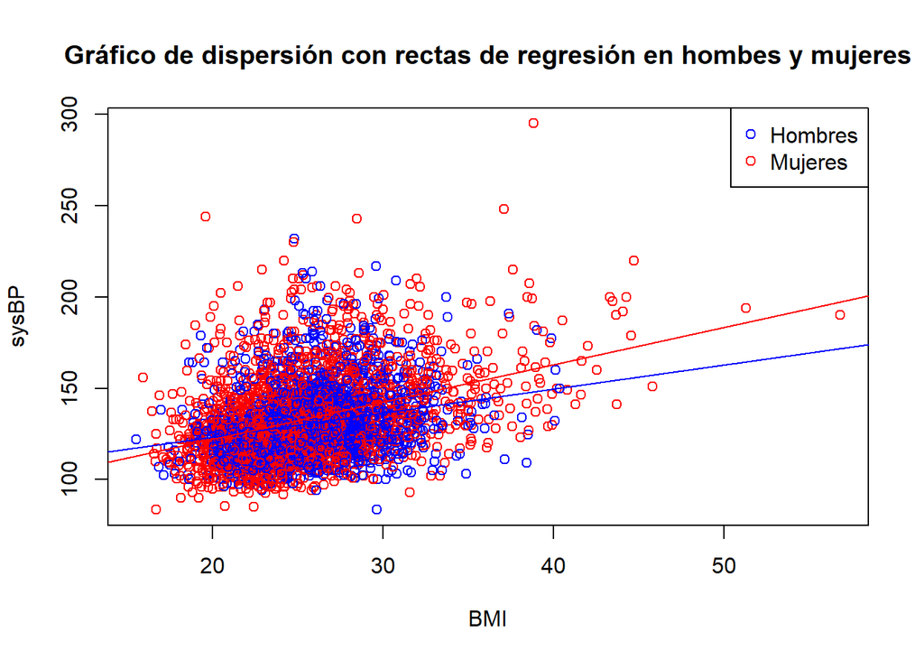

No obstante, la R-cuadrado ajustada (calculada en el apartado anterior) es del 12%, no podemos generalizar estas conclusiones a partir de las rectas de regresión, ya que el modelo no explica la mayor parte de la varianza del valor sysBP (88%).

Es por este motivo que si nos centramos en el gráfico de dispersión observamos una nube de puntos muy variable en el que tanto hombres y mujeres estan distribuidos sin una segmentación clara a simple vista.

### C)

```
##                 0.5 %     99.5 %
## (Intercept) 74.137826 87.7444529
## BMI          1.787986  2.3130589
## male         3.357257 28.0714240
## BMI:male    -1.197452 -0.2543371
```

[output not shown]

### D)

```r
# Estimar el modelo de regresión lineal múltiple ampliado
lmod_ampliado <- lm(sysBP ~ BMI * male + age + totChol + heartRate + currentSmoker + cigsPerDay + diabetes + glucose, data = mydat_no_NA)

# Mostrar un resumen del modelo
summary(lmod_ampliado)
```

```
##
## Call:
## lm(formula = sysBP ~ BMI * male + age + totChol + heartRate +
##     currentSmoker + cigsPerDay + diabetes + glucose, data = mydat_no_NA)
##
## Residuals:
##     Min      1Q  Median      3Q     Max
## -63.500 -12.559  -2.470   9.845 125.260
##
## Coefficients:
##                Estimate Std. Error t value Pr(>|t|)
## (Intercept)   18.488797   3.759859   4.917 9.16e-07 ***
## BMI            1.524050   0.095511  15.957  < 2e-16 ***
## male           7.802210   4.415597   1.767  0.07732 .
## age            0.817246   0.039397  20.744  < 2e-16 ***
## totChol        0.041561   0.007447   5.581 2.57e-08 ***
## heartRate      0.277341   0.026777  10.358  < 2e-16 ***
## currentSmoker -1.734338   1.004607  -1.726  0.08436 .
## cigsPerDay     0.045974   0.043355   1.060  0.28902
## diabetes      -0.643788   2.448616  -0.263  0.79263
## glucose        0.053617   0.016692   3.212  0.00133 **
## BMI:male      -0.358611   0.167898  -2.136  0.03275 *
## ---
## Signif. codes:  0 '***' 0.001 '**' 0.01 '*' 0.05 '.' 0.1 ' ' 1
##
## Residual standard error: 18.91 on 3647 degrees of freedom
## Multiple R-squared:  0.2688, Adjusted R-squared:  0.2668
## F-statistic: 134.1 on 10 and 3647 DF,  p-value: < 2.2e-16
```

Las hipótiesis que planteamos para testear el modelo son las siguientes:

- Hipótesis nula (H0): El modelo no explica de manera significativa la variabilidad de la variable de respuesta (sysBP). Por lo tanto, todos los coeficientes de regresión en el modelo son iguales a cero.
- Hipótesis alternativa (H1): El modelo explica de manera significativa la variabilidad de la variable de respuesta (sysBP). Al menos uno de los coeficientes de regresión en el modelo no es igual a cero.

Según el P-valor del test F (2.2e-16<0.05) el modelo es signficativo, consecuentemente, rechazamos H0 y así concluimos con que al menos uno de los coeficientes de regresión no es igual a cero.

Las variables significativas para este modelo son BMI, age, totChol, heartRate, glucose y la interacción BMI:male.

cigsPerDay es una variable NO signficativa (p-valor=0.28902>0.05) y por lo tanto no existe una relación significativa entre la cantidad de cigarrillos fumados por día y la presión arterial sistólica en este modelo.

### E)

```r
# Estimar el modelo de regresión lineal múltiple reducido
lmod_reducido <- lm(sysBP ~ BMI * male + age + totChol + heartRate + glucose, data = mydat_no_NA)
summary(lmod_reducido)
```

```
##
## Call:
## lm(formula = sysBP ~ BMI * male + age + totChol + heartRate +
##     glucose, data = mydat_no_NA)
##
## Residuals:
##     Min      1Q  Median      3Q     Max
## -64.132 -12.557  -2.481   9.712 125.357
##
## Coefficients:
##              Estimate Std. Error t value Pr(>|t|)
## (Intercept) 17.514789   3.569445   4.907 9.66e-07 ***
## BMI          1.541903   0.094793  16.266  < 2e-16 ***
## male         7.658613   4.396608   1.742 0.081604 .
## age          0.824803   0.038592  21.372  < 2e-16 ***
## totChol      0.041556   0.007438   5.587 2.48e-08 ***
## heartRate    0.276008   0.026587  10.381  < 2e-16 ***
## glucose      0.051109   0.013269   3.852 0.000119 ***
## BMI:male    -0.353461   0.167760  -2.107 0.035191 *
## ---
## Signif. codes:  0 '***' 0.001 '**' 0.01 '*' 0.05 '.' 0.1 ' ' 1
##
## Residual standard error: 18.91 on 3650 degrees of freedom
## Multiple R-squared:  0.2681, Adjusted R-squared:  0.2667
## F-statistic:   191 on 7 and 3650 DF,  p-value: < 2.2e-16
```

Las hipótiesis que planteamos para testear el si podemos reducir el modelo son las siguientes:

H0: β_1 = β_2 = β_3 = 0 (donde β_1, β_2, y β_3 son los coeficientes de las variables currentSmoker, cigsPerDay y diabetes respectivamente en el modelo completo). H1: al menos uno de los coeficientes β_1, β_2, o β_3 no es igual a cero.

```
## Analysis of Variance Table
##
## Model 1: sysBP ~ BMI * male + age + totChol + heartRate + glucose
## Model 2: sysBP ~ BMI * male + age + totChol + heartRate + currentSmoker +
##     cigsPerDay + diabetes + glucose
##   Res.Df     RSS Df Sum of Sq Pr(>Chi)
## 1   3650 1305628
## 2   3647 1304494  3    1134.7   0.3658
```

Para poder hacer un contraste de hipótesis utilizamos un Likelihood Ratio Test (LRT) en una distribución chi-cuadrado.

El p-valor>0.05 indica que no hay suficiente evidencia para rechazar H0 y, por lo tanto, los coeficientes de las variables currentSmoker, cigsPerDay y diabetes son igual a 0.

Este resultado demuestra que podemos utilitzar el modelo reducido. Además, si observamos su R-cuadrada ajustada (0.2667) podemos ver que se trata del mismo valor que la R-cuadrada ajustada del modelo ampliado, esto significa que el modelo reducido explica el mismo porcentaje de la varianza de sysBP con 3 variables menos, ya que no son variables significativas para la predicción de sysBP.

### F)

Para comprobar que los valores observados no suponen una extrapolación analizamos los rangos de las variables:

```
## [1] "Summary BMI"
```

```
##    Min. 1st Qu.  Median    Mean 3rd Qu.    Max.
##   15.54   23.08   25.38   25.78   28.04   56.80
```

```
## [1] "Summary Age"
```

```
##    Min. 1st Qu.  Median    Mean 3rd Qu.    Max.
##   32.00   42.00   49.00   49.55   56.00   70.00
```

```
## [1] "Summary totChol"
```

```
##    Min. 1st Qu.  Median    Mean 3rd Qu.    Max.
##   113.0   206.0   234.0   236.8   263.0   600.0
```

```
## [1] "Summary heartRate"
```

```
##    Min. 1st Qu.  Median    Mean 3rd Qu.    Max.
##   44.00   68.00   75.00   75.73   82.00  143.00
```

```
## [1] "Summary glucose"
```

```
##    Min. 1st Qu.  Median    Mean 3rd Qu.    Max.
##   40.00   71.00   78.00   81.85   87.00  394.00
```

Podemos observar que los valores BMI= 29, age = 64, male = 0, totCHol = 200, heartRate = 70 y glucose = 96 son valores que se encuentran dentro de los rangos establecidos en el summary de estas variables, por lo tanto los valores observados no suponen una extrapolación

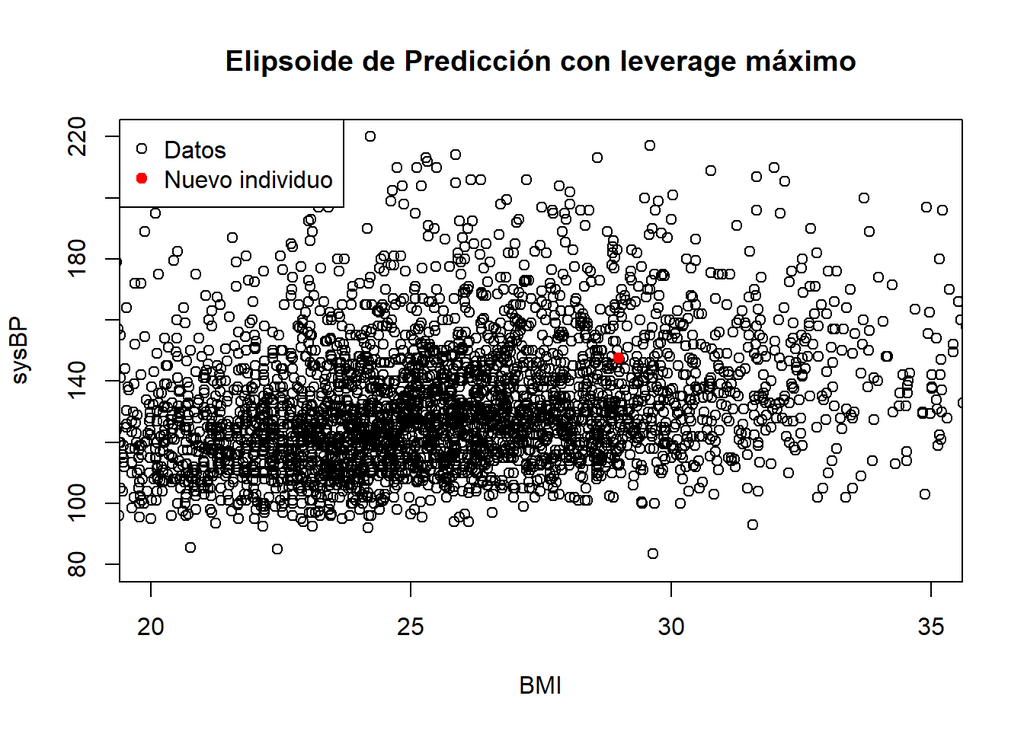

```
## Intervalo de predicción: 147.5556 110.4353 184.6759
```

## 2.

### A)

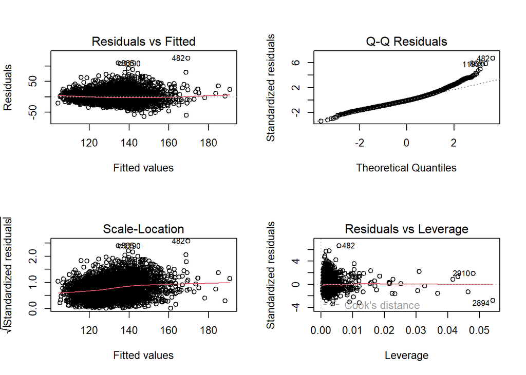

Gráfico 2: Observamos una recta que representa el ajuste de los residuos a una distribución normal. Los puntos que se encuentran situados en esta recta presentan un buen ajuste a una distribución normal. Observamos outliers positivos en los quantiles superiores. Esto indica que los errores del tercer quantil no siguen una distribución normal, lo cual podría afectar a la fiabilidad del modelo.

Gráfico 3: Al aplicar la raíz cuadrada del error cuadrático, estamos transformando los residuos para asegurar que siempre sean valores positivos. Esta transformación nos permite visualizar de manera más clara cómo se distribuyen los errores en relación con los valores ajustados. Idealmente, esperaríamos ver una dispersión uniforme alrededor de una línea recta horizontal, lo que indicaría que el modelo está capturando adecuadamente la variabilidad en los datos. Sin embargo, notamos un punto donde hay una escasez de datos en valores sistólicos altos, lo que significa que en esa región tenemos poca representación y menos datos para evaluar el rendimiento del modelo. Esta falta de datos puede influir en la interpretación de la calidad del ajuste en esa área específica.

Gráfico 4: Observamos el error de los residuos estandarizados en función de su leverage. Un punto de datos tiene alto leverage si tiene valores “extremos” en las variables predictoras. El gráfico nos permite visualizar el error de los valores con un mayor leverage. Podemos ver que los valores de más leverage tienen errores relativamente pequeños, esto quiere decir que existen puntos con variables predictoras con valores ‘extremos’ que tienen poco error. En canvio vemos que para puntos con menos leverage (con variables predictoras con valores no tan extremos) el error es mayor, lo cual indica un peor ajuste del modelo para variables de valores intermedios. La línea roja se ajusta sobre la linea central discontinua, lo cual indica un buen ajuste en términos generales.

```
##
##  studentized Breusch-Pagan test
##
## data:  lmod_reducido
## BP = 179.55, df = 7, p-value < 2.2e-16
```

```
## Non-constant Variance Score Test
## Variance formula: ~ fitted.values
## Chisquare = 315.0773, Df = 1, p = < 2.22e-16
```

Según estos dos test de homocedasticidad no podemos aceptar H0, ya que p-valor < 0.05, y por lo tanto los errores presentan heterocedasticidad y los valores de los residuos del modelo no son constantes.

Este suceso incumple una de las asunciones de Gauss-Markov para las Ordinary Least Squares Regression (OLS)

Esto significa que el método de mínimos cuadrados no es BLUE (Best Linear Unbiased Estimator) para nuestros datos y por lo tanto hay que usar otros métodos de ajuste para nuestra regresión como el Weighted Linear Squares, o transformar nuestros datos para que cumplan con las asumpciones de Gauss-Markov.

```
##
##  Shapiro-Wilk normality test
##
## data:  residuals(lmod_reducido)
## W = 0.95987, p-value < 2.2e-16
```

```
##
##  Asymptotic one-sample Kolmogorov-Smirnov test
##
## data:  residuals(lmod_reducido)
## D = 0.065072, p-value = 7.028e-14
## alternative hypothesis: two-sided
```

En ambos test el p-valor<0.05 y por lo tanto no podemos aceptar la H0, esto quiere decir que los residuos no siguen una distribución normal.

### B)

```r
# Cargar librerías necesarias
library(MASS)

# Estudio descriptivo de sysBP
summary(mydat_no_NA$sysBP)
```

```
##    Min. 1st Qu.  Median    Mean 3rd Qu.    Max.
##    83.5   117.0   128.0   132.4   143.9   295.0
```

```r
# Calcular la transformación logarítmica, no hemos podido usar logtrans debido al error:
#Error in object$y : $ operator is invalid for atomic vectors
mydat_no_NA$log_sysBP <- log(mydat_no_NA[, 11]+1)
log_sysBP <-mydat_no_NA$log_sysBP

# Ajustar un modelo de regresión lineal con la transformación logarítmica
lmod_log <- lm(log_sysBP ~ BMI * male + age + totChol + heartRate + glucose, data = mydat_no_NA)
summary(lmod_log)
```

```
##
## Call:
## lm(formula = log_sysBP ~ BMI * male + age + totChol + heartRate +
##     glucose, data = mydat_no_NA)
##
## Residuals:
##      Min       1Q   Median       3Q      Max
## -0.55344 -0.08948 -0.01018  0.07947  0.60855
##
## Coefficients:
##               Estimate Std. Error t value Pr(>|t|)
## (Intercept)  4.058e+00  2.525e-02 160.734  < 2e-16 ***
## BMI          1.095e-02  6.705e-04  16.333  < 2e-16 ***
## male         4.679e-02  3.110e-02   1.505 0.132535
## age          5.864e-03  2.730e-04  21.481  < 2e-16 ***
## totChol      3.207e-04  5.261e-05   6.095 1.21e-09 ***
## heartRate    1.988e-03  1.881e-04  10.573  < 2e-16 ***
## glucose      3.164e-04  9.386e-05   3.371 0.000756 ***
## BMI:male    -2.062e-03  1.187e-03  -1.738 0.082323 .
## ---
## Signif. codes:  0 '***' 0.001 '**' 0.01 '*' 0.05 '.' 0.1 ' ' 1
##
## Residual standard error: 0.1338 on 3650 degrees of freedom
## Multiple R-squared:  0.2721, Adjusted R-squared:  0.2707
## F-statistic: 194.9 on 7 and 3650 DF,  p-value: < 2.2e-16
```

[output not shown]

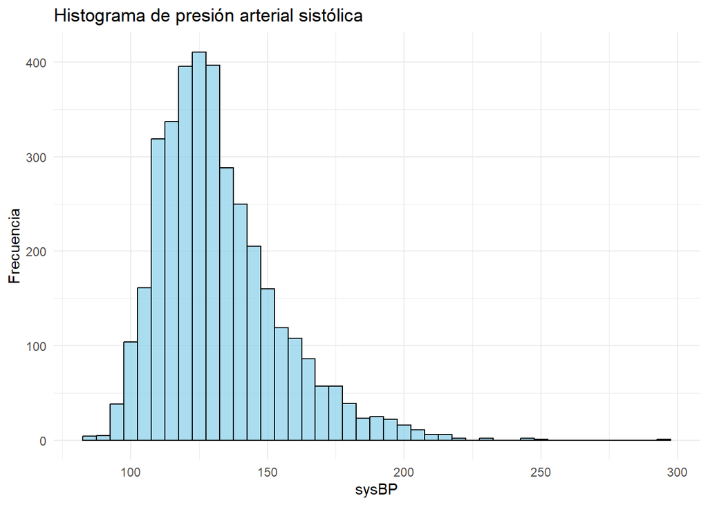

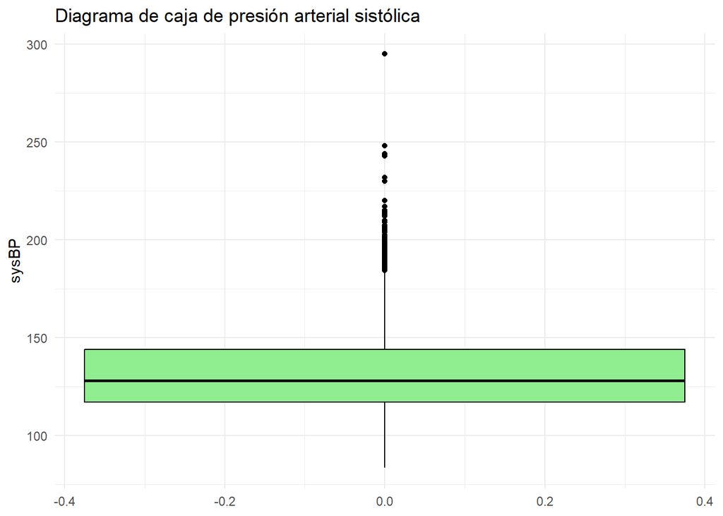

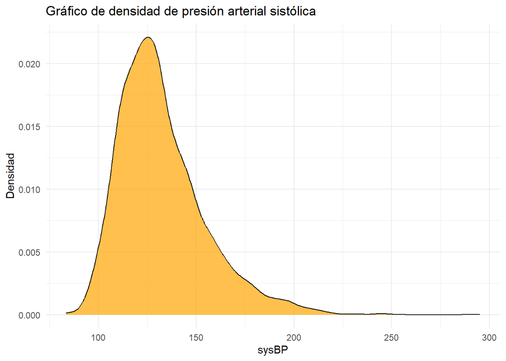

En el boxplot podemos apreciar algo similar y destacan algunos outliers en el márgen superior de la distribución (es lo que hemos observado en el qqplot del apartado anterior).

En el tercer gráfico observamos una estimación de la función de densidad de la variable sysBP donde podemos apreciar una oblicuidad positiva (como en el histograma) y la presencia de una cola positiva en la que encontramos los outliers que hemos detectado en el boxplot.

```
## Media de log_sysBP: 4.880462
##  Mediana de log_sysBP: 4.859812
##  Desviación estándar de log_sysBP: 0.1566494
##  Mínimo de log_sysBP: 4.436752
##  Máximo de log_sysBP: 5.690359
##  Rango intercuartílico de log_sysBP: 0.2051856
```

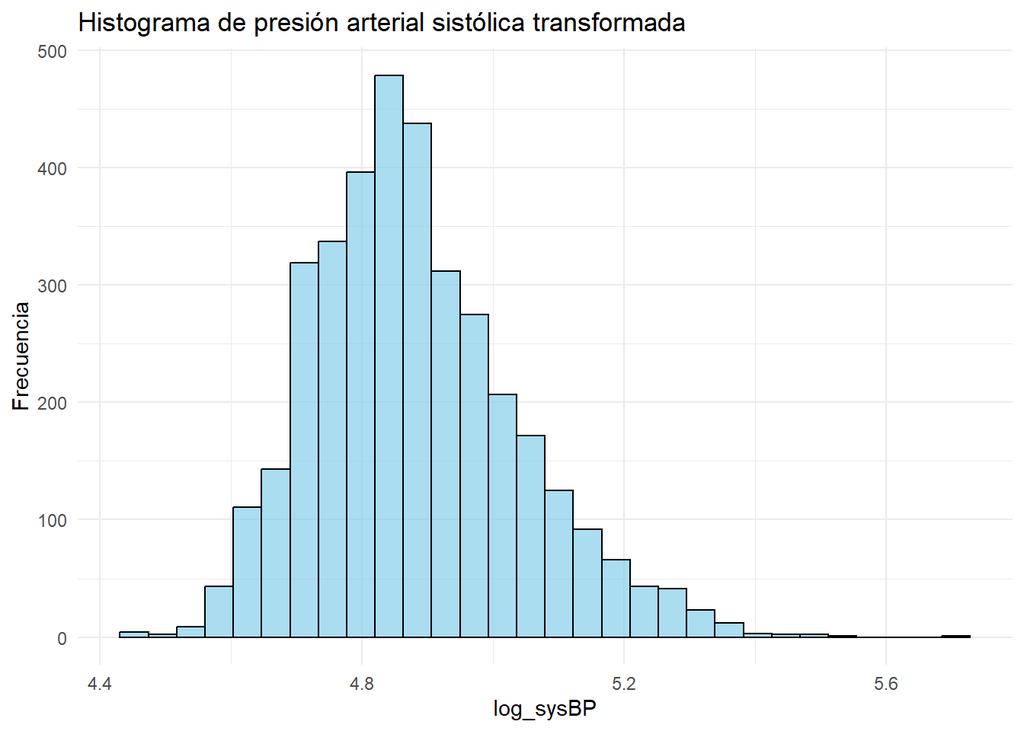

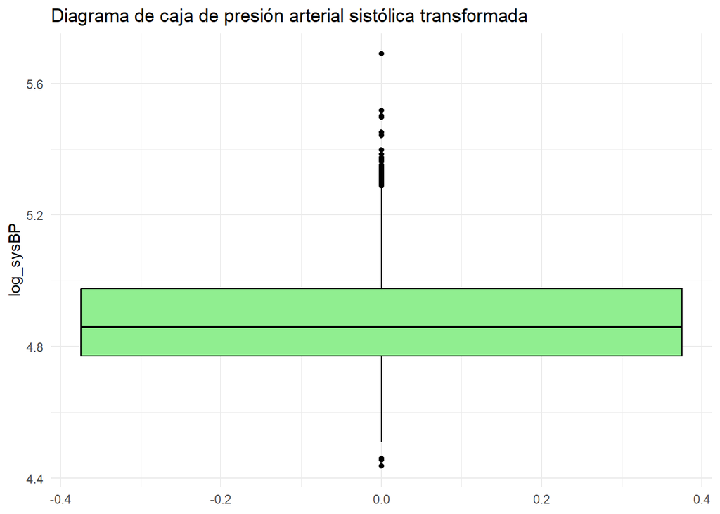

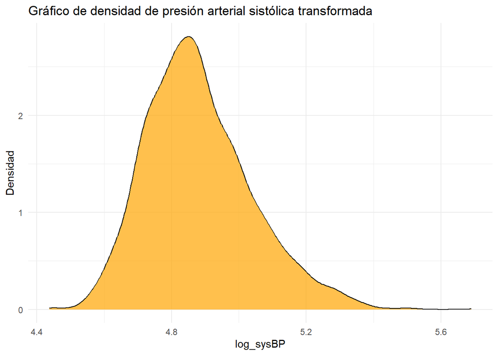

La aplicación de la transformación logarítmica a la variable sysBP ha resultado en una distribución más centrada, lo que se traduce en una mayor similitud con una distribución normal en comparación con los datos originales antes de la transformación y una aparente reducción parcial de los outliers positivos.

### C)

```r
# Ajustar un modelo de regresión lineal con la transformación logarítmica
lmod_log <- lm(log_sysBP ~ BMI * male + age + totChol + heartRate + glucose, data = mydat_no_NA)
summary(lmod_log)
```

```
##
## Call:
## lm(formula = log_sysBP ~ BMI * male + age + totChol + heartRate +
##     glucose, data = mydat_no_NA)
##
## Residuals:
##      Min       1Q   Median       3Q      Max
## -0.55344 -0.08948 -0.01018  0.07947  0.60855
##
## Coefficients:
##               Estimate Std. Error t value Pr(>|t|)
## (Intercept)  4.058e+00  2.525e-02 160.734  < 2e-16 ***
## BMI          1.095e-02  6.705e-04  16.333  < 2e-16 ***
## male         4.679e-02  3.110e-02   1.505 0.132535
## age          5.864e-03  2.730e-04  21.481  < 2e-16 ***
## totChol      3.207e-04  5.261e-05   6.095 1.21e-09 ***
## heartRate    1.988e-03  1.881e-04  10.573  < 2e-16 ***
## glucose      3.164e-04  9.386e-05   3.371 0.000756 ***
## BMI:male    -2.062e-03  1.187e-03  -1.738 0.082323 .
## ---
## Signif. codes:  0 '***' 0.001 '**' 0.01 '*' 0.05 '.' 0.1 ' ' 1
##
## Residual standard error: 0.1338 on 3650 degrees of freedom
## Multiple R-squared:  0.2721, Adjusted R-squared:  0.2707
## F-statistic: 194.9 on 7 and 3650 DF,  p-value: < 2.2e-16
```

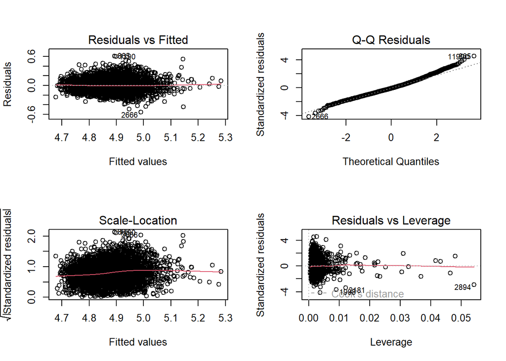

```
##
##  studentized Breusch-Pagan test
##
## data:  lmod_log
## BP = 143.97, df = 7, p-value < 2.2e-16
```

```
## Non-constant Variance Score Test
## Variance formula: ~ fitted.values
## Chisquare = 119.0677, Df = 1, p = < 2.22e-16
```

```
##
##  Shapiro-Wilk normality test
##
## data:  residuals(lmod_log)
## W = 0.98996, p-value = 2.003e-15
```

```
##
##  Asymptotic one-sample Kolmogorov-Smirnov test
##
## data:  residuals(lmod_log)
## D = 0.038706, p-value = 3.476e-05
## alternative hypothesis: two-sided
```

```r
par(mfrow = c(2, 2))

plot(lmod_log)
```

Aunque en el gráfico qqplot observamos una reducción de los outliers positivos y en el gráfico Scale-Location la linea roja presente un pendiente más plano y un mejor ajuste, los test normalidad y homocedaesticidad de los residuos de la variable transformada resultan en un p-valor<0.05 y por lo tanto rechazamos H0 en ambos test. Pese a haber realizado una trasformación log(sysBP+1) los test indican que los residuos del modelo lineal sobre la variable transformada siguen presentando heterocedasticidad y una distribución no normal. Esto implica que el ajuste del modelo por el método de mínimos cuadrados no es fiable, debido a que no se cumplen todas las asuncioes de Gauss-Markov.

### D)

```
## Valor leverage de los Top 3 puntos con mayor leverage: 0.05420254 0.04803521 0.04646945
```

```
##
## Leverage medio: 0.002186987
```

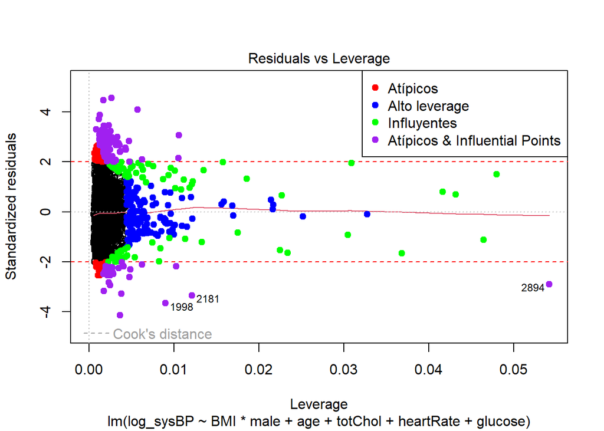

Este gráfico nos indica de forma visual cual es el leverage en relación al error estándar de los siguientes puntos: - Atípicos - De alto leverage - Influyentes (segun Cook’s distance) y aquellos - Atípicos e Influyentes

Los valores atípicos (rojo) son aquellos que presentan un valor inusual que no sigue el patrón de la recta de regresión. Los valores influyentes (verde) son aquellos que tienen un mayor peso en la determinación de los valores de los parámetros para el ajuste óptimo del modelo. Los valores atípicos e influyentes (lila) generalmente presentan error mayor a los puntos influyentes que no son atípicos. En el gráfico que observa a simple vista que aproximadamente la mitad de los valores influyentes son también valores atípicos. Esto indica que valores atípicos y con un error significativo han tenido una gran relevancia en el ajuste de los parámetros del modelo lineal.

### E)

```r
# Obtener las distancias de Cook
cook_distances <- cooks.distance(lmod_log)

# Ordenar las distancias de Cook de mayor a menor
sorted_cook <- sort(cook_distances, decreasing = TRUE)

# Obtener los índices de las tres observaciones más influyentes
top_influential_indices <- as.integer(names(sorted_cook)[1:3])

# Imprimir los índices de las observaciones más influyentes
print(top_influential_indices)
```

```
## [1] 2894 2181 1998
```

```r
outliers <- which(abs(rstandard(lmod_log)) > 2)

# Verificar si los puntos más influyentes son también atípicos
influential_outliers <- top_influential_indices %in% outliers

# Imprimir el resultado
print(influential_outliers)
```

```
## [1] FALSE FALSE FALSE
```

```r
# Eliminar las observaciones más influyentes
new_data <- mydat_no_NA[-as.numeric(top_influential_indices), ]

# Ajustar un nuevo modelo de regresión
lmod_new <- lm(sysBP ~ BMI * male + age + totChol + heartRate + glucose, data = new_data)
summary(lmod_new)
```

```
##
## Call:
## lm(formula = sysBP ~ BMI * male + age + totChol + heartRate +
##     glucose, data = new_data)
##
## Residuals:
##     Min      1Q  Median      3Q     Max
## -64.098 -12.538  -2.480   9.723 125.360
##
## Coefficients:
##              Estimate Std. Error t value Pr(>|t|)
## (Intercept) 17.501284   3.569457   4.903 9.85e-07 ***
## BMI          1.542318   0.094790  16.271  < 2e-16 ***
## male         7.629507   4.396336   1.735  0.08275 .
## age          0.824401   0.038602  21.356  < 2e-16 ***
## totChol      0.041828   0.007441   5.622 2.03e-08 ***
## heartRate    0.275278   0.026590  10.353  < 2e-16 ***
## glucose      0.051372   0.013272   3.871  0.00011 ***
## BMI:male    -0.353082   0.167748  -2.105  0.03537 *
## ---
## Signif. codes:  0 '***' 0.001 '**' 0.01 '*' 0.05 '.' 0.1 ' ' 1
##
## Residual standard error: 18.91 on 3647 degrees of freedom
## Multiple R-squared:  0.2684, Adjusted R-squared:  0.267
## F-statistic: 191.1 on 7 and 3647 DF,  p-value: < 2.2e-16
```

[figure not shown]

```
##
##  studentized Breusch-Pagan test
##
## data:  lmod_new
## BP = 179.57, df = 7, p-value < 2.2e-16
```

```
## Non-constant Variance Score Test
## Variance formula: ~ fitted.values
## Chisquare = 315.4149, Df = 1, p = < 2.22e-16
```

```
##
##  Shapiro-Wilk normality test
##
## data:  residuals(lmod_new)
## W = 0.95987, p-value < 2.2e-16
```

```
##
##  Asymptotic one-sample Kolmogorov-Smirnov test
##
## data:  residuals(lmod_new)
## D = 0.065018, p-value = 7.594e-14
## alternative hypothesis: two-sided
```

```r
par(mfrow = c(2, 2))

plot(lmod_log)
```

## 3.

### A)

```r
# Obtener la matriz de diseño del modelo
design_matrix <- model.matrix(lmod_new)

# Calcular el rango de la matriz de diseño
rank_design <- qr(design_matrix)$rank
cat('Rango: ', rank_design)
```

```
## Rango:  8
```

```r
# Calcular numero de parametros
num_col <- ncol(design_matrix)
cat('\nNumero parametros: ', num_col)
```

```
##
## Numero parametros:  8
```

El rango de la matriz de diseño coincide con el número de parámetros por lo tanto para hallar la solución deberemos resolver este Sistema Compatible Determinado de una única solución. Como la solución es única no tendremos problemas para estimar las combinaciones lineales de los parámetros.

### B)

Cuando el número de parámetros en el modelo es igual al rango de la matriz de diseño, significa que el sistema de ecuaciones normales tiene una solución única. Esto indica que cada parámetro del modelo puede ser estimado de manera única y precisa, y que el modelo es completamente identificable. En este caso, no hay colinealidad perfecta entre las variables predictoras, lo que garantiza que podamos encontrar una solución única.

Por otro lado, cuando el número de parámetros es diferente al rango de la matriz de diseño, significa que el sistema de ecuaciones normales tiene múltiples soluciones o ninguna solución. Esto puede ocurrir cuando hay colinealidad perfecta entre las variables predictoras. En tales casos, el modelo es “sobreparametrizado” y no se puede obtener una solución única para los parámetros del modelo.

Cuando hay múltiples soluciones, significa que hay infinitas combinaciones lineales de los parámetros correctas. Esto puede llevar a problemas de identificabilidad y a la falta de unicidad en la estimación de los parámetros. En tales casos, se necesitan técnicas adicionales, como:

- El cálculo de una de las posibles soluciones mediante la matriz G inversa
- La reducción a un modelo de rango máximo (mediante la eliminación de columnas linealmente dependientes o la imposición de restricciones en parámetros)

### C)

```r
# Extraer los coeficientes del modelo ajustado en el ejercicio 2(e)
coeficientes_ejercicio_2e <- coef(lmod_new)

# Calcular los coeficientes usando las ecuaciones normales
coeficientes_ecuaciones_normales <- solve(t(design_matrix) %*% design_matrix, t(design_matrix) %*% new_data$log_sysBP)


# Comparar los coeficientes
print(coeficientes_ejercicio_2e)
```

```
## (Intercept)         BMI        male         age     totChol   heartRate
## 17.50128430  1.54231752  7.62950658  0.82440084  0.04182804  0.27527797
##     glucose    BMI:male
##  0.05137205 -0.35308192
```

```r
print(coeficientes_ecuaciones_normales)
```

```
##                      [,1]
## (Intercept)  4.0581575536
## BMI          0.0109549811
## male         0.0465674817
## age          0.0058604316
## totChol      0.0003226034
## heartRate    0.0019832549
## glucose      0.0003182726
## BMI:male    -0.0020594054
```

El método de regresión lineal, utilizado para ajustar la recta de regresión mediante mínimos cuadrados, busca minimizar la suma de los cuadrados de las diferencias entre los valores observados y los predichos por el modelo. Este enfoque está diseñado para encontrar la mejor línea de ajuste que represente la relación entre las variables predictoras y la variable de respuesta.

### D)

```r
y <- new_data$log_sysBP
X <- design_matrix
MSE <- mean((y-X%*%coeficientes_ecuaciones_normales)^2)

# Calcular el intervalo de confianza del 95% para la varianza del error
alpha <- 0.05
n <- length(lmod_new$residuals)
lower_bound <- (n - 1) * MSE / qchisq(1 - alpha / 2, df = n - 1)
upper_bound <- (n - 1) * MSE / qchisq(alpha / 2, df = n - 1)

# Mostrar resultados
cat("Varianza del error (MSE):", MSE, "\n")
```

```
## Varianza del error (MSE): 0.01785354
```

```r
cat("Intervalo de confianza del 95% para la varianza del error:", lower_bound, "-", upper_bound, "\n")
```

```
## Intervalo de confianza del 95% para la varianza del error: 0.01706235 - 0.01870134
```

El error cuadrático medio (MSE) calculado es de aproximadamente 0.0179, lo que indica la dispersión promedio de los residuos respecto a la línea de regresión. El intervalo de confianza del 95% para la varianza del error está entre aproximadamente 0.0171 y 0.0187, lo que significa que tenemos un alto grado de certeza de que la verdadera varianza del error se encuentra dentro de este rango. Esto proporciona una medida de la precisión de nuestro modelo de regresión lineal y sugiere que los residuos están razonablemente bien distribuidos alrededor de la línea de regresión.

## Apéndices

### Código

Cargar los datos y eliminar NA values

```r
data <- read.csv('framingham.csv')

mydat_no_NA <- na.omit(data) #eliminamos missing values
```

1.B

```r
# Dibujar el gráfico de dispersión
plot(mydat_no_NA$BMI, mydat_no_NA$sysBP, col = ifelse(mydat_no_NA$male == 1, "blue", "red"),
     xlab = "BMI", ylab = "sysBP", main = "Gráfico de dispersión con rectas de regresión en hombes y mujeres")

# Agregar las rectas de regresión para hombres y mujeres
abline(lm(sysBP ~ BMI * male, data = mydat_no_NA[mydat_no_NA$male == 1,]), col = "blue")
abline(lm(sysBP ~ BMI * male, data = mydat_no_NA[mydat_no_NA$male == 0,]), col = "red")

# Agregar leyenda
legend("topright", legend = c("Hombres", "Mujeres"), col = c("blue", "red"), pch = 1)
```

1.C

```r
# Calcular los intervalos de confianza al 99% para los coeficientes del modelo
confianza_coeficientes <- confint(lmod_inicial, level = 0.99)
print(confianza_coeficientes)

# Calcular una estimación de la varianza del error en el mismo modelo
varianza_error <- sigma(lmod_inicial)
cat('Varianza del error: ', varianza_error)
```

1.E

```r
# Comparar los dos modelos utilizando el test de razón de verosimilitudes
anova_test <- anova(lmod_reducido, lmod_ampliado, test = "Chisq")

# Mostrar los resultados del test
print(anova_test)
```

1.F

```r
print('Summary BMI')
summary(mydat_no_NA$BMI)
print('Summary Age')
summary(mydat_no_NA$age)
print('Summary totChol')
summary(mydat_no_NA$totChol)
print('Summary heartRate')
summary(mydat_no_NA$heartRate)
print('Summary glucose')
summary(mydat_no_NA$glucose)


# Calcular la matriz de correlación
cor_matrix <- cov2cor(vcov(lmod_reducido))

# Calcular el leverage
leverage <- hatvalues(lmod_reducido)

# Encontrar el índice del valor de leverage máximo
max_leverage_index <- which.max(leverage)

# Calcular el elipsoide de predicción
elipsoide <- qnorm(0.975) * sqrt(leverage[max_leverage_index] * (1 + rowSums(cor_matrix^2)))

# Graficar el elipsoide
plot(NA, xlim = c(20, 35), ylim = c(80, 220), xlab = "BMI", ylab = "sysBP", main = "Elipsoide de Predicción con leverage máximo")
points(mydat_no_NA$BMI, mydat_no_NA$sysBP)
points(29, predict(lmod_reducido, newdata = data.frame(BMI=29, male=0, age=64, totChol=200, heartRate=70, glucose=96)), col = "red", pch = 19)
contour(outer(mydat_no_NA$BMI, elipsoide, "-"), add = TRUE) # Comprobamos que la variable se halla en el elipsoide de leverage maximo
legend("topleft", legend = c("Datos", "Nuevo individuo"), col = c("black", "red"), pch = c(1, 19))

# Calcular el intervalo de predicción al 95%
new_data <- data.frame(BMI=29, male=0, age=64, totChol=200, heartRate=70, glucose=96)
pred <- predict(lmod_reducido, newdata = new_data, interval = "prediction", level = 0.95)

# Mostrar el intervalo de predicción
cat('Intervalo de predicción:.'pred)
```

2.A

```r
par(mfrow = c(2, 2))


plot(lmod_reducido)


# Test de homocedasticidad
library(lmtest)
library(car)

# Breusch-Pagan Test
bp_test <- bptest(lmod_reducido)
print(bp_test)
# Score test for nonconstant error variance
ncvTest <- ncvTest(lmod_reducido)
print(ncvTest)


# Test de normalidad de los errores
# Shapiro-Wilk Test
shapiro_test <- shapiro.test(residuals(lmod_reducido))
print(shapiro_test)
# Kolmogorov-Smirnov Test
ks_test <- ks.test(residuals(lmod_reducido), "pnorm", mean = mean(residuals(lmod_reducido)), sd = sd(residuals(lmod_reducido)))
print(ks_test)
```

2.B

```r
# Cargar librerías necesarias
library(ggplot2)
par(mfrow = c(2, 2))

# Realizar el análisis descriptivo
mean_sysBP <- mean(mydat_no_NA$sysBP)
median_sysBP <- median(mydat_no_NA$sysBP)
sd_sysBP <- sd(mydat_no_NA$sysBP)
min_sysBP <- min(mydat_no_NA$sysBP)
max_sysBP <- max(mydat_no_NA$sysBP)
iqr_sysBP <- IQR(mydat_no_NA$sysBP)

# Mostrar medidas estadísticas
cat("Media de sysBP:", mean_sysBP, "\n","Mediana de sysBP:",
    median_log_sysBP, "\n",
    "Desviación estándar de sysBP:", sd_sysBP, "\n",
    "Mínimo de sysBP:", min_sysBP, "\n",
    "Máximo de sysBP:", max_sysBP, "\n",
    "Rango intercuartílico de sysBP:", iqr_sysBP, "\n")


# Crear visualizaciones
# Histograma
ggplot(mydat_no_NA, aes(x = sysBP)) +
  geom_histogram(binwidth = 5, fill = "skyblue", color = "black", alpha = 0.7) +
  labs(title = "Histograma de presión arterial sistólica", x = "sysBP", y = "Frecuencia") +
  theme_minimal()

# Diagrama de caja (Boxplot)
ggplot(mydat_no_NA, aes(y = sysBP)) +
  geom_boxplot(fill = "lightgreen", color = "black") +
  labs(title = "Diagrama de caja de presión arterial sistólica", y = "sysBP") +
  theme_minimal()

# Gráfico de densidad
ggplot(mydat_no_NA, aes(x = sysBP)) +
  geom_density(fill = "orange", color = "black", alpha = 0.7) +
  labs(title = "Gráfico de densidad de presión arterial sistólica", x = "sysBP", y = "Densidad") +
  theme_minimal()


# Analisis variable transformada
mean_log_sysBP <- mean(mydat_no_NA$log_sysBP)
median_log_sysBP <- median(mydat_no_NA$log_sysBP)
sd_log_sysBP <- sd(mydat_no_NA$log_sysBP)
min_log_sysBP <- min(mydat_no_NA$log_sysBP)
max_log_sysBP <- max(mydat_no_NA$log_sysBP)
iqr_log_sysBP <- IQR(mydat_no_NA$log_sysBP)

# Mostrar medidas estadísticas
cat("Media de log_sysBP:", mean_log_sysBP, "\n","Mediana de log_sysBP:",
    median_log_sysBP, "\n",
    "Desviación estándar de log_sysBP:", sd_log_sysBP, "\n",
    "Mínimo de log_sysBP:", min_log_sysBP, "\n",
    "Máximo de log_sysBP:", max_log_sysBP, "\n",
    "Rango intercuartílico de log_sysBP:", iqr_log_sysBP, "\n")


# Histograma
ggplot(mydat_no_NA, aes(x = log_sysBP)) +
  geom_histogram(fill = "skyblue", color = "black", alpha = 0.7) +
  labs(title = "Histograma de presión arterial sistólica transformada", x = "log_sysBP", y = "Frecuencia") +
  theme_minimal()

# Diagrama de caja (Boxplot)
ggplot(mydat_no_NA, aes(y = log_sysBP)) +
  geom_boxplot(fill = "lightgreen", color = "black") +
  labs(title = "Diagrama de caja de presión arterial sistólica transformada", y = "log_sysBP") +
  theme_minimal()

# Gráfico de densidad
ggplot(mydat_no_NA, aes(x = log_sysBP)) +
  geom_density(fill = "orange", color = "black", alpha = 0.7) +
  labs(title = "Gráfico de densidad de presión arterial sistólica transformada", x = "log_sysBP", y = "Densidad") +
  theme_minimal()
```

2.C

```r
# Test de homocedasticidad
library(lmtest)
library(car)

# Breusch-Pagan Test
bp_test <- bptest(lmod_log)
print(bp_test)
# Score test for nonconstant error variance
ncvTest <- ncvTest(lmod_log)
print(ncvTest)

# Test de normalidad de los errores
# Shapiro-Wilk Test
shapiro_test <- shapiro.test(residuals(lmod_log))
print(shapiro_test)
# Kolmogorov-Smirnov Test
ks_test <- ks.test(residuals(lmod_log), "pnorm", mean = mean(residuals(lmod_log)), sd = sd(residuals(lmod_log)))
print(ks_test)
```

2.D

```r
library(broom)
library(dplyr)

model_data <- augment(lmod_log) #.hat corresponde al leverage
#model_data
leverage_sorted <- model_data %>% arrange(desc(.hat)) #ordenamos valores por highest leverage

high_lev <- filter(model_data,.hat>3*mean(model_data$.hat)) # consideramos valores de alta influencia                                                             #aquellos que triplican el mean leverage
cat('Valor leverage de los Top 3 puntos con mayor leverage:',leverage_sorted$.hat[1:3])
cat('\nLeverage medio:',mean(model_data$.hat))


# Identificar valores atípicos
outliers <- which(abs(rstandard(lmod_log)) > 2)

# Identificar puntos de alto leverage
high_leverage <- which(hatvalues(lmod_log) > 2 * mean(hatvalues(lmod_log)))

# Identificar puntos influyentes
influential_points <- which(cooks.distance(lmod_log) > 4 / nrow(mydat_no_NA))

outliers_influential <- intersect(outliers, influential_points)

# Crear gráfico resumen
plot(lmod_log, which = 5)  # Gráfico de Influencia vs. Residuos Estudentizados y Gráfico de Residuos Estudentizados
abline(h = c(2, -2), col = "red", lty = 2)  # Líneas para identificar valores atípicos
points(model_data$.hat[outliers], rstandard(lmod_log)[outliers], col = "red", pch = 19)  # Resaltar valores atípicos
points(model_data$.hat[high_leverage], rstandard(lmod_log)[high_leverage], col = "blue", pch = 19)  # Resaltar puntos de alto leverage
points(model_data$.hat[influential_points], rstandard(lmod_log)[influential_points], col = "green", pch = 19)  # Resaltar puntos influyentes
points(model_data$.hat[outliers_influential], rstandard(lmod_log)[outliers_influential], col = "purple", pch = 19)
legend("topright", legend = c("Atípicos", "Alto leverage", "Influyentes", "Atípicos & Influential Points"), col = c("red", "blue", "green", "purple"), pch = 19)
```

2.E

```r
# Test de homocedasticidad
library(lmtest)
library(car)

# Breusch-Pagan Test
bp_test <- bptest(lmod_new)
print(bp_test)
# Score test for nonconstant error variance
ncvTest <- ncvTest(lmod_new)
print(ncvTest)

# Test de normalidad de los errores
# Shapiro-Wilk Test
shapiro_test <- shapiro.test(residuals(lmod_new))
print(shapiro_test)
# Kolmogorov-Smirnov Test
ks_test <- ks.test(residuals(lmod_new), "pnorm", mean = mean(residuals(lmod_new)), sd = sd(residuals(lmod_new)))
print(ks_test)
```